# Lista de agrupamentos

Davi Wentrick Feijó

2023-07-16

## 76. Johnson e Wichern - Exercício 12.3.

Sabemos que o $r$ (correlacao) pode ser obtido por meio da seguinte formula:

$$r = \frac{\sum (x_i-\bar{x})(y_i-\bar{y})}{\sqrt{\sum
(x_i-\bar{x})^2(y_i-\bar{y})^2}}$$

Sabemos que:

$$\bar{x} = \frac{a+b}{p} \ \ \ \ \ \ \bar{y} = \frac{a+c}{p}$$
$$x_1 = a+b \ \ \ \ \ \ \ x_2 = b+c$$
$$y_1 = a+c \ \ \ \ \ \ \ y_2 = b+d$$
onde $p$ é o total:

$$p = a+b+c+d$$

Agora vamos encontrar os seguintes resultados:

$$\sum (x_i-\bar{x})^2 = (a+b)(1-\frac{a+b}{p})^2 +
(c+d)(0-\frac{a+b}{p})^2 = \frac{(a+b)+(c+d)}{p}$$
$$\sum (x_i-\bar{x})^2 = (a+c)(1-\frac{a+c}{p})^2 +
(b+d)(0-\frac{a+c}{p})^2 = \frac{(a+c)+(b+d)}{p}$$
$$\sum (x_i-\bar{x})(y_i-\bar{y}) = \sum
(x_iy_i-y_i\bar{x}-x_i\bar{y}+\bar{x}\bar{y})$$
$$\sum (x_iy_i-y_i\bar{x}-x_i\bar{y}+\bar{x}\bar{y}) = a +
\frac{(a+c)+(a+b)}{p} - \\ \frac{(a+b)+(a+c)}{p} + p
\frac{(a+b)+(a+c)}{p^2} + \\ \frac{a(a+b+c+d)-(a+c)(a+b)}{p} =
\frac{ad-bc}{p}$$

Com isso podemos chegar:

$$r = \frac{\sum (x_i-\bar{x})(y_i-\bar{y})}{\sqrt{\sum
(x_i-\bar{x})^2(y_i-\bar{y})^2}} =
\frac{\frac{ad-bc}{p}}{\sqrt{(\frac{(a+b)+(c+d)}{p})(\frac{(a+c)+(b+d)}{p})}}$$
$$r =
\frac{\frac{ad-bc}{p}}{\sqrt{(\frac{(a+b)+(c+d)}{p})(\frac{(a+c)+(b+d)}{p})}}
= \frac{\frac{ad-bc}{p}}{(\frac{(a+b)+(c+d)+(a+c)+(b+d)}{p^2})}$$
$$r = \frac{\frac{ad-bc}{p}}{(\frac{(a+b)+(c+d)+(a+c)+(b+d)}{p^2})} =
\frac{ad-bc}{[(a+b)+(c+d)+(a+c)+(b+d)]^{1/2}}$$

## 77. Johnson e Wichern - Exercício 12.5.

```r
m <- matrix(c(0 ,1,11,5,
              1 ,0,2,3,
              11,2,0,4,
              5 ,3,4,0),nrow=4,byrow = T)

(d <- as.dist(m))
```

```
##    1  2  3
## 2  1
## 3 11  2
## 4  5  3  4
```

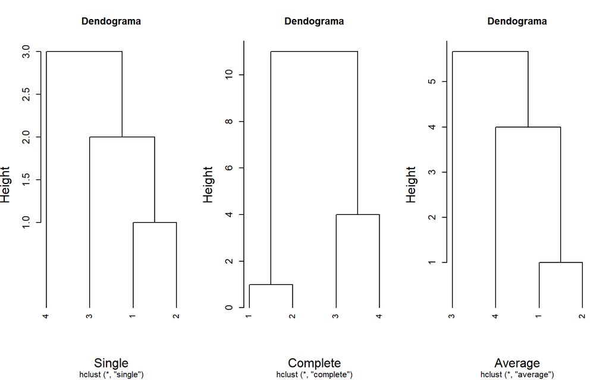

```r
par(mfrow=c(1, 3))
hcs <- hclust(d, "single")

plot(hcs, hang = -1, cex.axis=1.2, cex.lab = 1.5,
     xlab="Single", main="Dendograma")
hcc <- hclust(d, "complete")

plot(hcc, hang = -1, cex.axis=1.2, cex.lab = 1.5,
     xlab="Complete", main="Dendograma")

hcc <- hclust(d, "average")

plot(hcc, hang = -1, cex.axis=1.2, cex.lab = 1.5,
     xlab="Average", main="Dendograma")
```

## 78. Johnson e Wichern - Exercício 12.6

```r
m <- matrix(c(0 ,4,6,1,6,
              4 ,0,9,7,3,
              6 ,9,0,10,5,
              1 ,7,10,0,8,
              6 ,3,5,8,0),nrow=5,byrow = T)

(d <- as.dist(m))
```

```
##    1  2  3  4
## 2  4
## 3  6  9
## 4  1  7 10
## 5  6  3  5  8
```

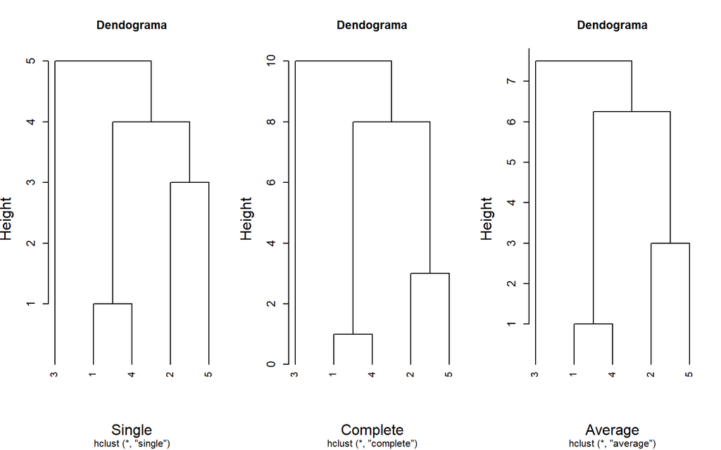

```r
par(mfrow=c(1, 3))
hcs <- hclust(d, "single")

plot(hcs, hang = -1, cex.axis=1.2, cex.lab = 1.5,
     xlab="Single", main="Dendograma")
hcc <- hclust(d, "complete")

plot(hcc, hang = -1, cex.axis=1.2, cex.lab = 1.5,
     xlab="Complete", main="Dendograma")

hcc <- hclust(d, "average")

plot(hcc, hang = -1, cex.axis=1.2, cex.lab = 1.5,
     xlab="Average", main="Dendograma")
```

## 79. Johnson e Wichern - Exercício 12.7

```r
m <- matrix(c(1 ,0.63,0.51,0.12,0.16,
              0.63 ,1,0.57,0.32,0.21,
              0.51 ,0.57,1,0.18,0.15,
              0.12 ,0.32,0.18,1,0.68,
              0.16 ,0.21,0.15,0.68,1),nrow=5,byrow = T)

colnames(m) <- c("JP Morgan","Citibank","Wells Fargo","Royal DutchShell","Exxon Mobil")
rownames(m) <- c("JP Morgan","Citibank","Wells Fargo","Royal DutchShell","Exxon Mobil")


(d <- as.dist(m))
```

```
##                  JP Morgan Citibank Wells Fargo Royal DutchShell
## Citibank              0.63
## Wells Fargo           0.51     0.57
## Royal DutchShell      0.12     0.32        0.18
## Exxon Mobil           0.16     0.21        0.15             0.68
```

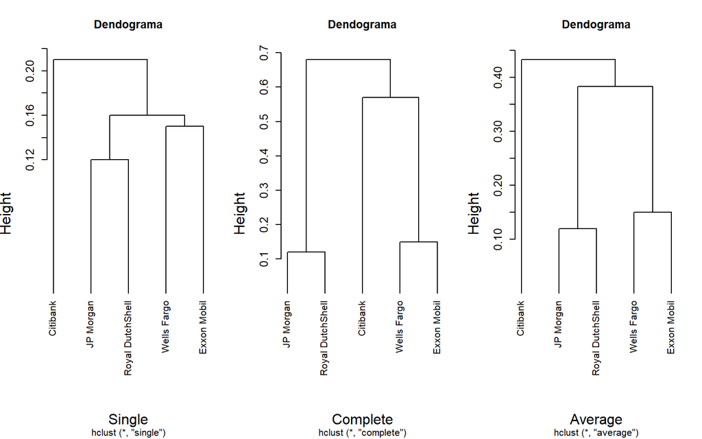

```r
par(mfrow=c(1, 3))
hcs <- hclust(d, "single")

plot(hcs, hang = -1, cex.axis=1.2, cex.lab = 1.5,
     xlab="Single", main="Dendograma")
hcc <- hclust(d, "complete")

plot(hcc, hang = -1, cex.axis=1.2, cex.lab = 1.5,
     xlab="Complete", main="Dendograma")

hcc <- hclust(d, "average")

plot(hcc, hang = -1, cex.axis=1.2, cex.lab = 1.5,
     xlab="Average", main="Dendograma")
```

## 80. Johnson e Wichern - Exercício 12.11

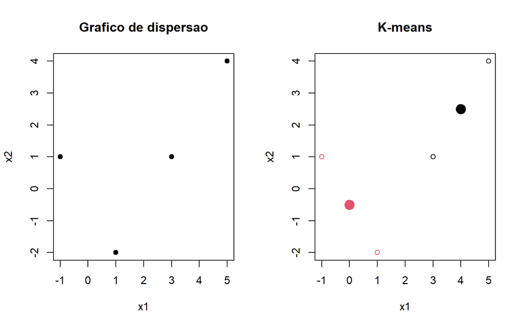

```r
x1 = c(5,1,-1,3)
x2 = c(4,-2,1,1)
dados = data.frame(x1,x2)

kc = data.frame(dados[c(1,2),])

cl1 <- kmeans(dados, centers = kc)

par(mfrow=c(1, 2))
plot(dados, pch=19,cex=1,main="Grafico de dispersao")

plot(dados, col = cl1$cluster,main="K-means")

points(cl1$centers, col = 1:2, pch = 19, cex=2)
```

## 81. Johnson e Wichern - Exercício 12.12

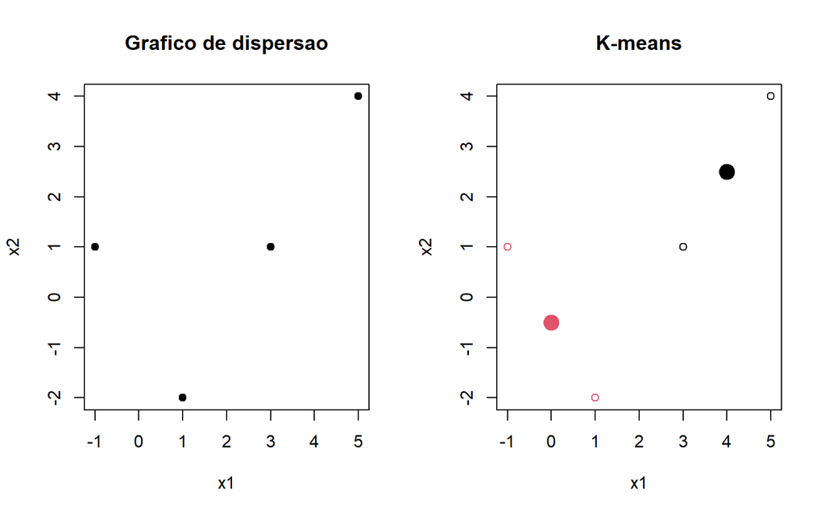

```r
x1 = c(5,1,-1,3)
x2 = c(4,-2,1,1)
dados = data.frame(x1,x2)

kc = data.frame(dados[c(1,3),])

cl1 <- kmeans(dados, centers = kc)

par(mfrow=c(1, 2))
plot(dados, pch=19,cex=1,main="Grafico de dispersao")

plot(dados, col = cl1$cluster,main="K-means")

points(cl1$centers, col = 1:2, pch = 19, cex=2)
```

## 83. Considere o seguinte conjunto de 22 pontos (x, y).

```r
ponto = c(1:22)
x = c(1,2,2,2,3,7,12,13,13,14,14,15,7,6,7,8,6,7,8,6,7,8)
y = c(9,10,9,8,9,14,9,10,8,10,8,9,7,3,3,3,2,2,2,1,1,1)

dados = data.frame(ponto,x,y)
```

[output not shown]

### (a) Plote o gráfico de dispersão para o conjunto de pontos. Quantos e quais grupos você indicaria através do gráfico.

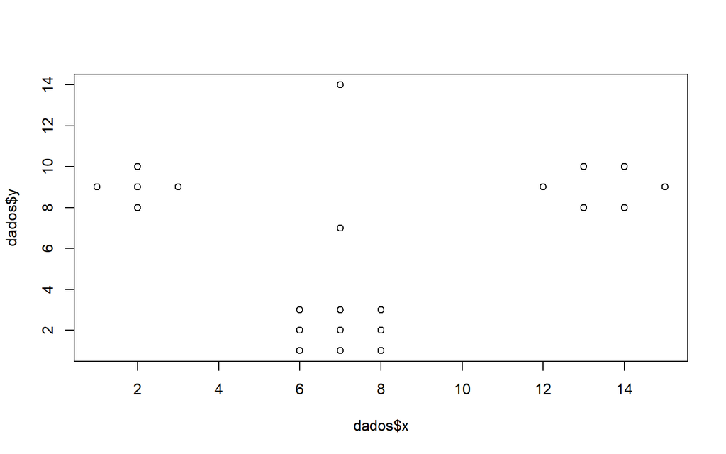

```r
plot(dados$x,dados$y)
```

### (b) Construa a matriz de distâncias D, calculando as distâncias Euclidiana, de Manhattan e Mahalanobis. Compare os resultados. Explique a razão de possíveis diferenças nos resultados para as três distâncias.

```r
(d1 <- dist(dados[,c(2,3)],method="euclidean",diag=F))
```

```
##            1         2         3         4         5         6         7
## 2   1.414214
## 3   1.000000  1.000000
## 4   1.414214  2.000000  1.000000
## 5   2.000000  1.414214  1.000000  1.414214
## 6   7.810250  6.403124  7.071068  7.810250  6.403124
## 7  11.000000 10.049876 10.000000 10.049876  9.000000  7.071068
## 8  12.041595 11.000000 11.045361 11.180340 10.049876  7.211103  1.414214
## 9  12.041595 11.180340 11.045361 11.000000 10.049876  8.485281  1.414214
## 10 13.038405 12.000000 12.041595 12.165525 11.045361  8.062258  2.236068
## 11 13.038405 12.165525 12.041595 12.000000 11.045361  9.219544  2.236068
## 12 14.000000 13.038405 13.000000 13.038405 12.000000  9.433981  3.000000
## 13  6.324555  5.830952  5.385165  5.099020  4.472136  7.000000  5.385165
## 14  7.810250  8.062258  7.211103  6.403124  6.708204 11.045361  8.485281
## 15  8.485281  8.602325  7.810250  7.071068  7.211103 11.000000  7.810250
## 16  9.219544  9.219544  8.485281  7.810250  7.810250 11.045361  7.211103
## 17  8.602325  8.944272  8.062258  7.211103  7.615773 12.041595  9.219544
## 18  9.219544  9.433981  8.602325  7.810250  8.062258 12.000000  8.602325
## 19  9.899495 10.000000  9.219544  8.485281  8.602325 12.041595  8.062258
## 20  9.433981  9.848858  8.944272  8.062258  8.544004 13.038405 10.000000
## 21 10.000000 10.295630  9.433981  8.602325  8.944272 13.000000  9.433981
## 22 10.630146 10.816654 10.000000  9.219544  9.433981 13.038405  8.944272
##            8         9        10        11        12        13        14
## 2
## 3
## 4
## 5
## 6
## 7
## 8
## 9   2.000000
## 10  1.000000  2.236068
## 11  2.236068  1.000000  2.000000
## 12  2.236068  2.236068  1.414214  1.414214
## 13  6.708204  6.082763  7.615773  7.071068  8.246211
## 14  9.899495  8.602325 10.630146  9.433981 10.816654  4.123106
## 15  9.219544  7.810250  9.899495  8.602325 10.000000  4.000000  1.000000
## 16  8.602325  7.071068  9.219544  7.810250  9.219544  4.123106  2.000000
## 17 10.630146  9.219544 11.313708 10.000000 11.401754  5.099020  1.000000
## 18 10.000000  8.485281 10.630146  9.219544 10.630146  5.000000  1.414214
```

[output cut: 11 more lines]

```
## 8
## 9
## 10
## 11
## 12
## 13
## 14
## 15
## 16  1.000000
## 17  1.414214  2.236068
## 18  1.000000  1.414214  1.000000
## 19  1.414214  1.000000  2.000000  1.000000
## 20  2.236068  2.828427  1.000000  1.414214  2.236068
## 21  2.000000  2.236068  1.414214  1.000000  1.414214  1.000000
## 22  2.236068  2.000000  2.236068  1.414214  1.000000  2.000000  1.000000
```

```r
(d2 <- dist(dados[,c(2,3)],method="manhattan",diag=F))
```

```
##     1  2  3  4  5  6  7  8  9 10 11 12 13 14 15 16 17 18 19 20 21
## 2   2
## 3   1  1
## 4   2  2  1
## 5   2  2  1  2
## 6  11  9 10 11  9
## 7  11 11 10 11  9 10
## 8  13 11 12 13 11 10  2
## 9  13 13 12 11 11 12  2  2
## 10 14 12 13 14 12 11  3  1  3
## 11 14 14 13 12 12 13  3  3  1  2
## 12 14 14 13 14 12 13  3  3  3  2  2
## 13  8  8  7  6  6  7  7  9  7 10  8 10
## 14 11 11 10  9  9 12 12 14 12 15 13 15  5
## 15 12 12 11 10 10 11 11 13 11 14 12 14  4  1
## 16 13 13 12 11 11 12 10 12 10 13 11 13  5  2  1
## 17 12 12 11 10 10 13 13 15 13 16 14 16  6  1  2  3
## 18 13 13 12 11 11 12 12 14 12 15 13 15  5  2  1  2  1
## 19 14 14 13 12 12 13 11 13 11 14 12 14  6  3  2  1  2  1
## 20 13 13 12 11 11 14 14 16 14 17 15 17  7  2  3  4  1  2  3
## 21 14 14 13 12 12 13 13 15 13 16 14 16  6  3  2  3  2  1  2  1
## 22 15 15 14 13 13 14 12 14 12 15 13 15  7  4  3  2  3  2  1  2  1
```

### (c) Utilize os algoritmos de ligação simples e média, e obtenha os respectivos dendogramas. Em cada caso indique sua escolha para o número de grupos e liste os elementos de cada grupo. Os dendogramas obtidos são únicos? Justifique.

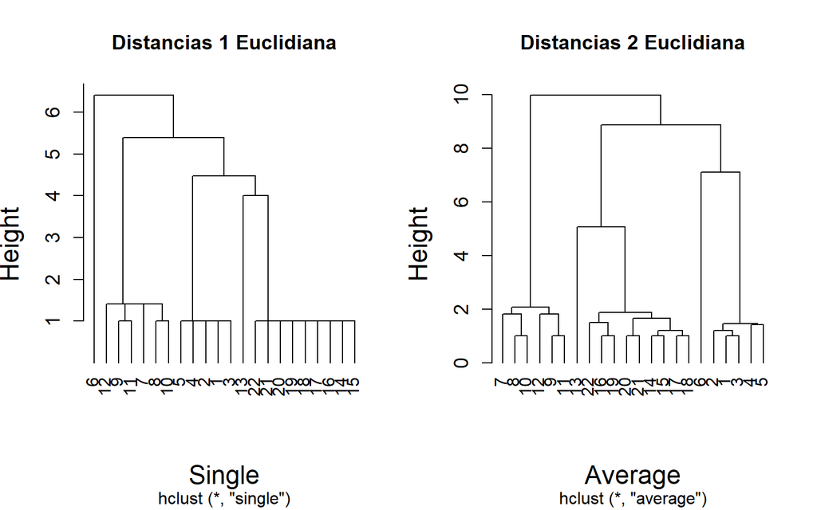

```r
par(mfrow=c(1, 2))
hcs <- hclust(d1, "single")
plot(hcs, hang = -1, cex.axis=1.2, cex.lab = 1.5,
     xlab="Single", main="Distancias 1 Euclidiana")

hcc <- hclust(d1, "average")
plot(hcc, hang = -1, cex.axis=1.2, cex.lab = 1.5,
     xlab="Average", main="Distancias 2 Euclidiana")
```

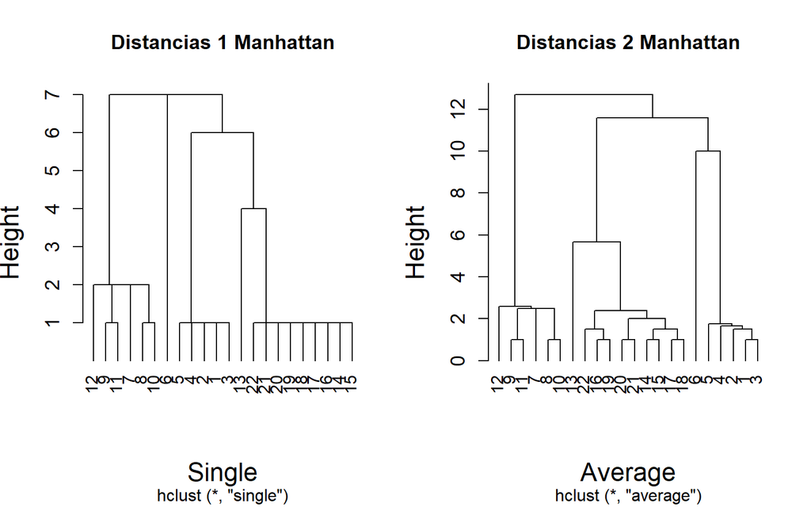

```r
par(mfrow=c(1, 2))
hcs <- hclust(d2, "single")
plot(hcs, hang = -1, cex.axis=1.2, cex.lab = 1.5,
     xlab="Single", main="Distancias 1 Manhattan")

hcc <- hclust(d2, "average")
plot(hcc, hang = -1, cex.axis=1.2, cex.lab = 1.5,
     xlab="Average", main="Distancias 2 Manhattan")
```

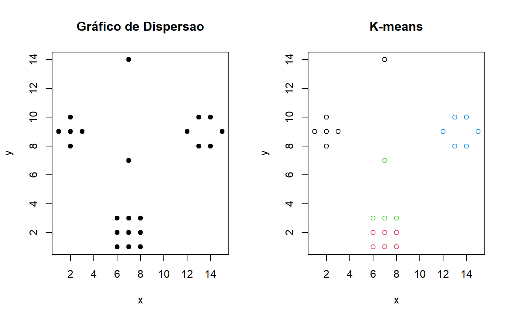

```r
par(mfrow=c(1, 2))
cl1 <- kmeans(dados[,c(2,3)],4)

plot(dados[,c(2,3)], pch=19, main="Gráfico de Dispersao")

plot(dados[,c(2,3)], col = cl1$cluster,, main="K-means")
```

## 84. Seis variáveis são medidas de 100 notas genuínas e 100 notas falsificadas (Flury and Riedwyl, 1988.)

```
##   Status Length  Left Right Bottom  Top Diagonal
## 1      0  214.8 131.0 131.1    9.0  9.7    141.0
## 2      0  214.6 129.7 129.7    8.1  9.5    141.7
## 3      0  214.8 129.7 129.7    8.7  9.6    142.2
## 4      0  214.8 129.7 129.6    7.5 10.4    142.0
## 5      0  215.0 129.6 129.7   10.4  7.7    141.8
## 6      0  215.7 130.8 130.5    9.0 10.1    141.4
```

### (a) Calcule as médias de cada variável em cada população (notas verdadeiras e falsificadas). Obtenha também a matriz de variância-covariâncias Σ em cada população. Obtenha um face plot de cada população utilizando os valores médios. Compare os resultados númericos com os gráficos. Discuta. Utilize o face plot para comparar os valores médios das variáveis para notas verdadeiras e notas falsas. Discuta os resultados.

Medidas resumo das notas verdadeiras

```r
summary(bank[bank$Status == 0,])
```

```
##      Status      Length           Left           Right           Bottom
##  Min.   :0   Min.   :213.8   Min.   :129.0   Min.   :129.0   Min.   : 7.200
##  1st Qu.:0   1st Qu.:214.7   1st Qu.:129.7   1st Qu.:129.4   1st Qu.: 7.900
##  Median :0   Median :215.0   Median :129.9   Median :129.7   Median : 8.250
##  Mean   :0   Mean   :215.0   Mean   :129.9   Mean   :129.7   Mean   : 8.305
##  3rd Qu.:0   3rd Qu.:215.2   3rd Qu.:130.2   3rd Qu.:130.0   3rd Qu.: 8.800
##  Max.   :0   Max.   :215.9   Max.   :131.0   Max.   :131.1   Max.   :10.400
##       Top            Diagonal
##  Min.   : 7.700   Min.   :139.6
##  1st Qu.: 9.775   1st Qu.:141.2
##  Median :10.200   Median :141.5
##  Mean   :10.168   Mean   :141.5
##  3rd Qu.:10.600   3rd Qu.:141.8
##  Max.   :11.700   Max.   :142.4
```

Medidas resumo das notas falsas

```r
summary(bank[bank$Status == 1,])
```

```
##      Status      Length           Left           Right           Bottom
##  Min.   :1   Min.   :213.9   Min.   :129.6   Min.   :129.3   Min.   : 7.40
##  1st Qu.:1   1st Qu.:214.6   1st Qu.:130.1   1st Qu.:130.0   1st Qu.: 9.90
##  Median :1   Median :214.8   Median :130.3   Median :130.2   Median :10.60
##  Mean   :1   Mean   :214.8   Mean   :130.3   Mean   :130.2   Mean   :10.53
##  3rd Qu.:1   3rd Qu.:215.0   3rd Qu.:130.5   3rd Qu.:130.4   3rd Qu.:11.40
##  Max.   :1   Max.   :216.3   Max.   :130.8   Max.   :131.1   Max.   :12.70
##       Top           Diagonal
##  Min.   : 9.10   Min.   :137.8
##  1st Qu.:10.68   1st Qu.:139.2
##  Median :11.10   Median :139.5
##  Mean   :11.13   Mean   :139.4
##  3rd Qu.:11.53   3rd Qu.:139.8
##  Max.   :12.30   Max.   :140.6
```

### (b) Utilize um método de agrupamento para verificar se é possível distiguir as notas falsas das verdadeiras, imaginando que você não soubesse se 100 últimas notas eram verdadeiras.

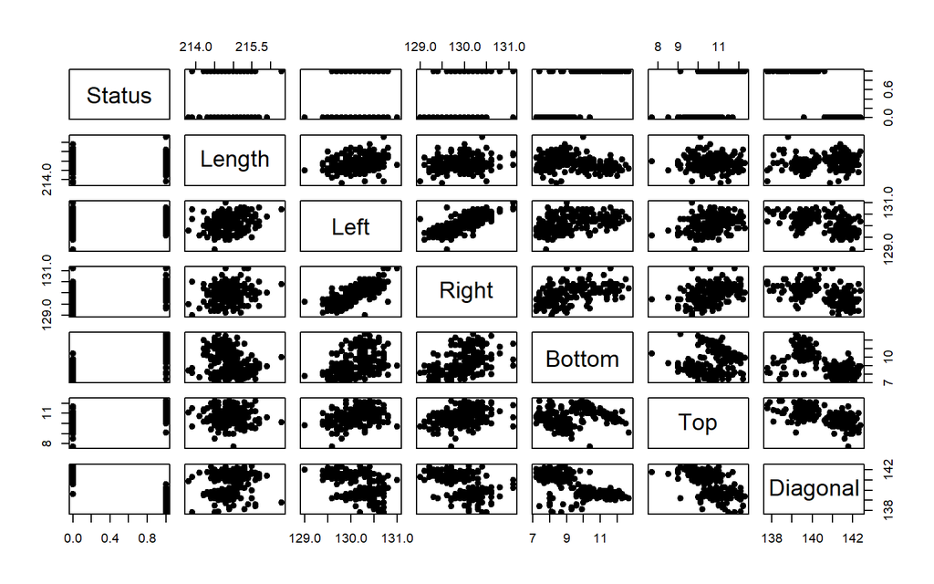

```r
cl1 <- kmeans(bank,2)

plot(bank, pch=19)
```

Podemos notar pela matriz de dispersao das variaveis do banco que a diagonal da nota parece agrupar bem as observacoes em relacao as outras variaveis. Por isso optou-se por plotar a matriz de dispersao da Diagonal da nota pela largura da parte superior.

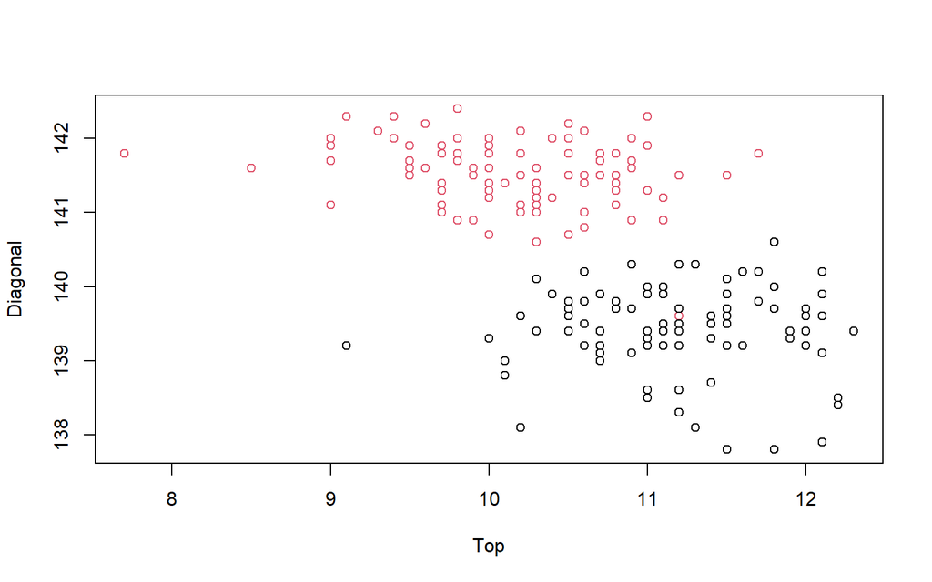

```r
plot(bank[,c(6,7)], col = cl1$cluster)
```

### (c) Compare os resultados do agrupamento anterior com o agrupamento por mistura de normais

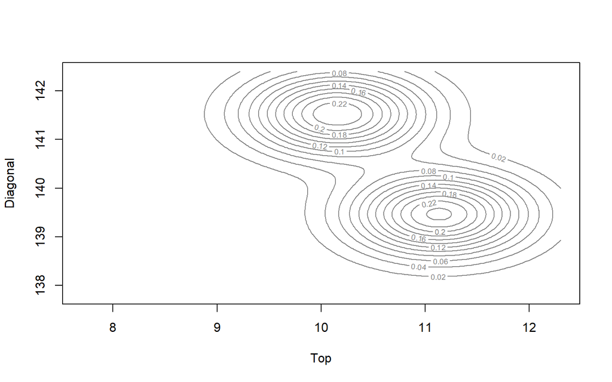

### (d) Utilize o Índice Ajustado de Rand para comparar seu agrupamento das 200 notas com a verdadeira classificação em genuínas e falsas. Avalie a qualidade do agrupamento.

Comparando os resultados do k-mean com a verdadeira calssificacao

```r
adjustedRandIndex(cl1$cluster,bank$Status)
```

```
## [1] 1
```

Comparando os resultados da mistura de normais com a verdadeira calssificacao

```r
adjustedRandIndex(cl1$cluster,bank_den$classification)
```

```
## [1] 0.9799995
```